# STAT 650 - Final Project

### [2-2-2 Desciptive analysis](https://github.com/yoojunT/STAT650_Final_Assignment/blob/main/Section%202-2-2%20EDA_Multicollinearity.ipynb)

In line with the defined temporal scope, basic statistical analyses of the errors are illustrated in the figure below, which shows no missing values in the dataset. For this project, additional pre-processing steps, such as data cleaning and normalization, were not undertaken. This decision stems from the intent to utilize the ultimate regression model, as discussed in RH3, in real-world scenarios where such processing may not be feasible due to time constraints and practical application considerations. Moreover, to maintain consistency across different climate regions, the project has deliberately minimized further pre-processing, taking into account these practical aspects and the need for uniformity in variable treatment.

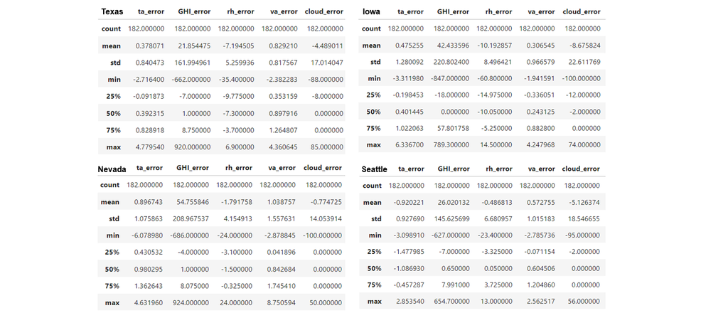

### [2-2-3 Multicollinearity](https://github.com/yoojunT/STAT650_Final_Assignment/blob/main/Section%202-2-2%20EDA_Multicollinearity.ipynb)

For RH3, this project intends to employ a regression-based approac following the instructions. In this regard, multicollinearity is a critical factor in selecting suitable regression models. The figure belowrepresents that all variables in the datasets exhibit weak multicollinearity, as indicated by Variance Inflation Factors (VIF) below 10. This information is vital for both feature selection and model determination within the context of regression analysis. The low levels of multicollinearity among the variables not only validate the appropriateness of using regression models but also ensure the reliability and interpretability of the results derived from these models.

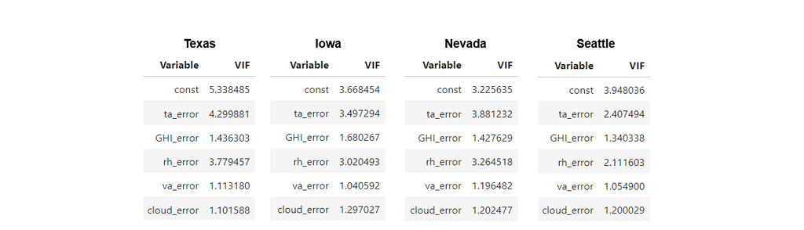